# 关于帕尔默企鹅数据集的探索

#### 8.2 企鹅性别的预测

性别是一个二分类问题，这里我们可以直接使用ROC曲线来进行模型选取

```python
# 在不同阈值上计算fpr
# 得到 fpr  tpr  阀值（ROC）
# 得到AUC  面积
def plot_roc_curve(y_test, preds):
    fpr, tpr, threshold = metrics.roc_curve(y_test, preds)
    roc_auc = metrics.auc(fpr, tpr)
    plt.title('Receiver Operating Characteristic')
    plt.plot(fpr, tpr, 'b', label = 'AUC = %0.2f' % roc_auc)
    plt.legend(loc = 'lower right')
    plt.plot([0, 1], [0, 1],'r--')
    plt.xlim([-0.01, 1.01])
    plt.ylim([-0.01, 1.01])
    plt.ylabel('True Positive Rate')
    plt.xlabel('False Positive Rate')
    plt.show()
```

```python
X = df[['culmen_length_mm', 'culmen_depth_mm', 'flipper_length_mm','body_mass_g']]
y = df['sex']
X_train, X_test, y_train, y_test = train_test_split(X, y, test_size=0.2, random_state=42)
```

```python
# 逻辑回归
train_pred_log, test_pred_log, acc_log, acc_cv_log, probs_log = fit_ml_algo(LogisticRegression(),
                                                                 X_train,
                                                                 y_train,
                                                                 X_test,
                                                                 y_test,
                                                                 10)
print(f"Accuracy: {acc_log}")
print(f"Accuracy CV 10-Fold: {acc_cv_log}")
```

```
Accuracy: 52.24
Accuracy CV 10-Fold: 73.68
```

```python
print (metrics.classification_report(y_test, test_pred_log))
```

```
              precision    recall  f1-score   support

           0       0.63      0.32      0.43        37
           1       0.48      0.77      0.59        30

    accuracy                           0.52        67
   macro avg       0.56      0.55      0.51        67
weighted avg       0.56      0.52      0.50        67
```

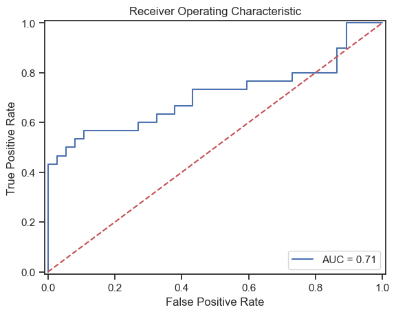

```python
plot_roc_curve(y_test, probs_log)
```

```python
# 决策树
train_pred_dt, test_pred_dt, acc_dt, acc_cv_dt, probs_dt = fit_ml_algo(DecisionTreeClassifier(),
                                                                 X_train,
                                                                 y_train,
                                                                 X_test,
                                                                 y_test,
                                                                 10)
print(f"Accuracy: {acc_dt}")
print(f"Accuracy CV 10-Fold: {acc_cv_dt}")
```

```
Accuracy: 83.58
Accuracy CV 10-Fold: 76.69
```

```python
print (metrics.classification_report(y_test, test_pred_dt))
```

```
              precision    recall  f1-score   support

           0       0.84      0.86      0.85        37
           1       0.83      0.80      0.81        30

    accuracy                           0.84        67
   macro avg       0.83      0.83      0.83        67
weighted avg       0.84      0.84      0.84        67
```

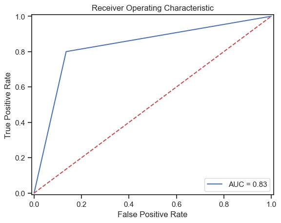

```python
plot_roc_curve(y_test, probs_dt)
```

```python
# 随机森林
train_pred_rf, test_pred_rf, acc_rf, acc_cv_rf, probs_rf = fit_ml_algo(RandomForestClassifier(),
                                                                 X_train,
                                                                 y_train,
                                                                 X_test,
                                                                 y_test,
                                                                 10)
print(f"Accuracy: {acc_rf}")
print(f"Accuracy CV 10-Fold: {acc_cv_rf}")
```

```
Accuracy: 83.58
Accuracy CV 10-Fold: 81.95
```

```python
print (metrics.classification_report(y_test, test_pred_rf))
```

```
              precision    recall  f1-score   support

           0       0.86      0.84      0.85        37
           1       0.81      0.83      0.82        30

    accuracy                           0.84        67
   macro avg       0.83      0.84      0.83        67
weighted avg       0.84      0.84      0.84        67
```

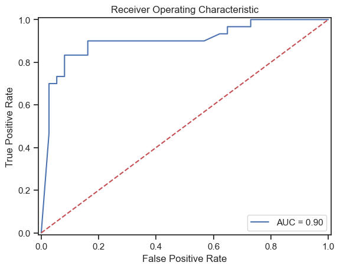

```python
plot_roc_curve(y_test, probs_rf)
```

```python
# 准确率排序
models = pd.DataFrame({
    'Model': ['LogisticRegression','DecisionTreeClassifier','RandomForestClassifier'],
    'Score': [
        acc_log,
        acc_dt,
        acc_rf,
    ]})
models.sort_values(by='Score', ascending=False)
```

|  | Model | Score |
| --- | --- | --- |
| 1 | DecisionTreeClassifier | 83.58 |
| 2 | RandomForestClassifier | 83.58 |
| 0 | LogisticRegression | 52.24 |

```python
# 再计算特征重要度
model = DecisionTreeClassifier()
model.fit(X_train,y_train)
feature_importance = pd.DataFrame({
    'Feature': X_train.columns,
    'Importance': model.feature_importances_
})
sorted_feature_importance = feature_importance.sort_values(by='Importance', ascending=False)
sorted_feature_importance
```

|  | Feature | Importance |
| --- | --- | --- |
| 1 | culmen_depth_mm | 0.457637 |
| 0 | culmen_length_mm | 0.415287 |
| 3 | body_mass_g | 0.065174 |
| 2 | flipper_length_mm | 0.061902 |

### 聚类分析：K-means算法

```python
# 先进行数据的转换，转换为series数据集
# 使用身体特征的数据进行聚类分析
df_s = df[['culmen_length_mm','culmen_depth_mm','flipper_length_mm','body_mass_g']]
X = df_s.values
```

```python
X.shape
```

```
(333, 4)
```

```python
# 四维图形没法绘制，我们使用PCA降为二维
pca = PCA(n_components=2)
reduced_data = pca.fit_transform(X)
```

```python
# 聚类结果的总内部距离平方和
kmeans_per_k = [KMeans(n_clusters = k).fit(reduced_data) for k in range(2,10)]
inertias = [model.inertia_ for model in kmeans_per_k]
```

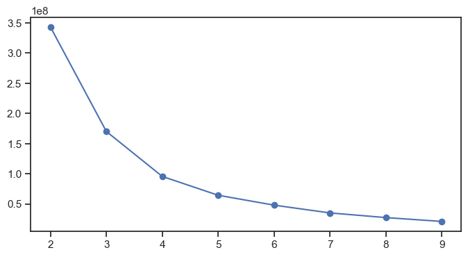

```python
plt.figure(figsize=(8,4))
plt.plot(range(2,10),inertias,'bo-')
plt.show()
```

惯性值持续下降，在k=5之后，稍微平缓

```python
# 分别计算不同分类的轮廓系数
silhouette_scores = [silhouette_score(X,model.labels_) for model in kmeans_per_k[1:]]
silhouette_scores
```

```
[0.5805281868676646,
 0.5541854635320633,
 0.5423470842912249,
 0.5227424959398291,
 0.5326506602609898,
 0.5380847872230899,
 0.5439193516167004]
```

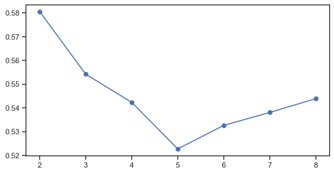

```python
plt.figure(figsize=(8,4))
plt.plot(range(2,len(silhouette_scores)+2),silhouette_scores,'bo-')
plt.show()
```

```python
k =5
kmeans = KMeans(n_clusters = k,random_state=42)
y_pred =  kmeans.fit_predict(reduced_data)
```

```python
def plot_data(X):
    plt.plot(X[:, 0], X[:, 1], 'k.', markersize=2)

def plot_centroids(centroids, weights=None, circle_color='w', cross_color='k'):
    if weights is not None:
        centroids = centroids[weights > weights.max() / 10]
    plt.scatter(centroids[:, 0], centroids[:, 1],
                marker='o', s=30, linewidths=8,
                color=circle_color, zorder=10, alpha=0.9)
    plt.scatter(centroids[:, 0], centroids[:, 1],
                marker='x', s=50, linewidths=50,
                color=cross_color, zorder=11, alpha=1)

# 中心点的展示

def plot_decision_boundaries(clusterer, X, resolution=1000, show_centroids=True,
                             show_xlabels=True, show_ylabels=True):
    mins = X.min(axis=0) - 0.1
    maxs = X.max(axis=0) + 0.1
    xx, yy = np.meshgrid(np.linspace(mins[0], maxs[0], resolution),
                         np.linspace(mins[1], maxs[1], resolution))
    Z = clusterer.predict(np.c_[xx.ravel(), yy.ravel()])
    Z = Z.reshape(xx.shape)

    plt.contourf(Z, extent=(mins[0], maxs[0], mins[1], maxs[1]),
                cmap="Pastel2")
    plt.contour(Z, extent=(mins[0], maxs[0], mins[1], maxs[1]),
                linewidths=1, colors='k')

    #绘制等高线
    plot_data(X)
    if show_centroids:
        plot_centroids(clusterer.cluster_centers_)

    if show_xlabels:
        plt.xlabel("$x_1$", fontsize=14)
    else:
        plt.tick_params(labelbottom='off')
    if show_ylabels:
        plt.ylabel("$x_2$", fontsize=14, rotation=0)
    else:
        plt.tick_params(labelleft='off')
```

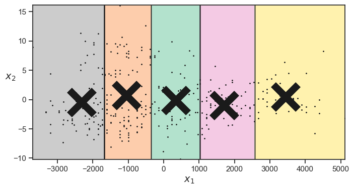

```python
plt.figure(figsize=(8, 4))
plot_decision_boundaries(kmeans, reduced_data)
plt.show()
```

```python
# 模型确定后重新计算轮廓系数
silhouette_score(reduced_data,kmeans.labels_)
```

```
0.5368997645591398
```

```python
# 中心点坐标
kmeans.cluster_centers_
```

```
array([[ 3.43105992e+02, -1.47028581e-01],
       [-1.04598761e+03,  7.57485158e-01],
       [ 1.71359149e+03, -9.38267443e-01],
       [ 3.44756026e+03,  4.63294475e-01],
       [-2.31108468e+03, -4.47599242e-01]])
```

```python
kmeans.inertia_
```

```
65244130.231175445
```